# 目录 🌐

- **1.数据分析概述🔐**
- **2.数据导入及预处理⏳**
  - 库的导入
  - 数据的导入
  - 缺失数据填充
  - 复合数据拆分
- **3.数据分析 🔍**
  - 数据可视化，挖掘变量的潜在关系
  - 男女睡眠差异性的假设检验
- **4.总结评论📝**
  - 对于该数据分析的综述与总结
  - 对我们项目的理论指导意义

# 数据分析概述 🔐

- **探索健康的生活方式：** 睡眠质量是健康生活方式的主要产物之一。我们一生中大约有三分之一的时间是在睡觉——或者至少我们应该在睡觉。各种在食物中闪闪发光的食物。不幸的是，我们中的许多人没有达到这个目标。根据美国国立卫生研究院的数据，失眠影响了大约三分之一的普通人群，使其成为美国最常见的睡眠障碍。以下是您需要了解的有关睡眠的信息。
- **对项目提供理论的指导意义：** 通过数据分析得到的各关键变量之间的关系，而成品的设计有一个自适应、机器学习的逻辑，研究变量的底层逻辑关系，能对项目的机器学习机理作出符合实际的理论指导，这是对于一个产品而言最重要的——实用性。

数据来源：https://www.kaggle.com/datasets/uom190346a/sleep-health-and-lifestyle-dataset

数据下载链接：https://github.com/Chenxinjun488/CQU_SRTP_Report.github.io/blob/main/Sleep_health_and_lifestyle_dataset.csv

关于数据集： 数据集包含以下列：

- 个人ID
- 性别
- 年龄
- 职业
- 睡眠时长 - 平均每天的小时数
- 睡眠质量 - 主观评分从1到10
- 体力活动水平 - 平均每天参与活动的时间（分钟）
- 压力水平 - 主观评分从1到10
- 身体质量指数（BMI）分类
- 血压
- 心率
- 每日步数
- 睡眠障碍 - 无、失眠、睡眠呼吸暂停

# 数据导入及预处理 ⏳

```python
# type:ignore
import pandas as pd  #开源的数据分析和操作库，结构化数据集的有力工具
import numpy as np #开源 Python科学计算库，能够处理大型数据，加快运行速度
import matplotlib.pyplot as plt # 可视化工具
import seaborn as sns # 统计可视化的有力工具
from scipy import stats # 科学计算
import warnings #用于忽略type警告，使页面干净整洁
warnings.filterwarnings('ignore')
warnings.simplefilter('ignore')
```

> **注 ：以下操作旨在对数据进行预处理（包括缺失值的处理，复合列元素的拆分）和初步的数据探索**

```python
data = pd.read_csv(r"E:\Code\JupyterCode\Sleep_health_and_lifestyle_dataset.csv")
missing_values = data.isnull().sum()
print(missing_values) # 定位缺失值
```

```
Person ID                    0
Gender                       0
Age                          0
Occupation                   0
Sleep Duration               0
Quality of Sleep             0
Physical Activity Level      0
Stress Level                 0
BMI Category                 0
Blood Pressure               0
Heart Rate                   0
Daily Steps                  0
Sleep Disorder             219
dtype: int64
```

```python
data['Sleep Disorder'].fillna('Unknown', inplace=True) # 填充缺失值为“Unknown”
# 确认“睡眠障碍”列中没有遗漏值
print("填入后'Sleep Disorder'列中的缺失值的个数： ", data['Sleep Disorder'].isnull().sum())
```

```
填入后'Sleep Disorder'列中的缺失值的个数：  0
```

```python
data.head() # 展示数据的前五行
```

|  | Person ID | Gender | Age | Occupation | Sleep Duration | Quality of Sleep | Physical Activity Level | Stress Level | BMI Category | Blood Pressure | Heart Rate | Daily Steps | Sleep Disorder |
| --- | --- | --- | --- | --- | --- | --- | --- | --- | --- | --- | --- | --- | --- |
| 0 | 1 | Male | 27 | Software Engineer | 6.1 | 6 | 42 | 6 | Overweight | 126/83 | 77 | 4200 | Unknown |
| 1 | 2 | Male | 28 | Doctor | 6.2 | 6 | 60 | 8 | Normal | 125/80 | 75 | 10000 | Unknown |
| 2 | 3 | Male | 28 | Doctor | 6.2 | 6 | 60 | 8 | Normal | 125/80 | 75 | 10000 | Unknown |
| 3 | 4 | Male | 28 | Sales Representative | 5.9 | 4 | 30 | 8 | Obese | 140/90 | 85 | 3000 | Sleep Apnea |
| 4 | 5 | Male | 28 | Sales Representative | 5.9 | 4 | 30 | 8 | Obese | 140/90 | 85 | 3000 | Sleep Apnea |

如上表格所示，“Sleep Disorder”一列的缺失值被填充为“Unknown”

```python
data.describe() # 展示数据的数字特征
```

|  | Person ID | Age | Sleep Duration | Quality of Sleep | Physical Activity Level | Stress Level | Heart Rate | Daily Steps |
| --- | --- | --- | --- | --- | --- | --- | --- | --- |
| count | 374.000000 | 374.000000 | 374.000000 | 374.000000 | 374.000000 | 374.000000 | 374.000000 | 374.000000 |
| mean | 187.500000 | 42.184492 | 7.132086 | 7.312834 | 59.171123 | 5.385027 | 70.165775 | 6816.844920 |
| std | 108.108742 | 8.673133 | 0.795657 | 1.196956 | 20.830804 | 1.774526 | 4.135676 | 1617.915679 |
| min | 1.000000 | 27.000000 | 5.800000 | 4.000000 | 30.000000 | 3.000000 | 65.000000 | 3000.000000 |
| 25% | 94.250000 | 35.250000 | 6.400000 | 6.000000 | 45.000000 | 4.000000 | 68.000000 | 5600.000000 |
| 50% | 187.500000 | 43.000000 | 7.200000 | 7.000000 | 60.000000 | 5.000000 | 70.000000 | 7000.000000 |
| 75% | 280.750000 | 50.000000 | 7.800000 | 8.000000 | 75.000000 | 7.000000 | 72.000000 | 8000.000000 |
| max | 374.000000 | 59.000000 | 8.500000 | 9.000000 | 90.000000 | 8.000000 | 86.000000 | 10000.000000 |

上述表格展示了数据集中的数字数据的数字特征，包括均值(mean)，无偏标准差(std)，最值，25%分位数，50%分位数，75%分位数

下面将着手于相关系数矩阵的可视化

```python
# 为相关系数矩阵的绘制做初步的数据处理
data_encoded = pd.get_dummies(data, columns=['Gender'], drop_first=True)  # Drop_first 避免多重公线性
data_encoded.head() # 展示数据的前5行
```

|  | Person ID | Age | Occupation | Sleep Duration | Quality of Sleep | Physical Activity Level | Stress Level | BMI Category | Blood Pressure | Heart Rate | Daily Steps | Sleep Disorder | Gender_Male |
| --- | --- | --- | --- | --- | --- | --- | --- | --- | --- | --- | --- | --- | --- |
| 0 | 1 | 27 | Software Engineer | 6.1 | 6 | 42 | 6 | Overweight | 126/83 | 77 | 4200 | Unknown | True |
| 1 | 2 | 28 | Doctor | 6.2 | 6 | 60 | 8 | Normal | 125/80 | 75 | 10000 | Unknown | True |
| 2 | 3 | 28 | Doctor | 6.2 | 6 | 60 | 8 | Normal | 125/80 | 75 | 10000 | Unknown | True |
| 3 | 4 | 28 | Sales Representative | 5.9 | 4 | 30 | 8 | Obese | 140/90 | 85 | 3000 | Sleep Apnea | True |
| 4 | 5 | 28 | Sales Representative | 5.9 | 4 | 30 | 8 | Obese | 140/90 | 85 | 3000 | Sleep Apnea | True |

```python
# 将血压柱分为收缩压和舒张压部分
data_encoded[['Systolic BP', 'Diastolic BP']] = data_encoded['Blood Pressure'].str.split('/', expand=True)

# 将收缩压和舒张压分量转换为数值
data_encoded['Systolic BP'] = pd.to_numeric(data_encoded['Systolic BP'], errors='coerce')
data_encoded['Diastolic BP'] = pd.to_numeric(data_encoded['Diastolic BP'], errors='coerce')

# 可选：对血压进行分类
def categorize_blood_pressure(row):
    systolic = row['Systolic BP']
    diastolic = row['Diastolic BP']
    if systolic < 120 and diastolic < 80:
        return 'Normal'
    elif 120 <= systolic < 130 and diastolic < 80:
        return 'Elevated'
    elif 130 <= systolic < 140 or 80 <= diastolic < 90:
        return 'Stage 1 Hypertension'
    elif 140 <= systolic or 90 <= diastolic:
        return 'Stage 2 Hypertension'
    else:
        return 'Unknown'
data_encoded['Blood Pressure Category'] = data_encoded.apply(categorize_blood_pressure, axis=1)
```

在上述过程中，我们首先使用 .str.split（） 方法将 DataFrame 的“血压”列拆分为收缩压和舒张压部分，并为每个列创建单独的列。然后，我们将这些组件转换为数值，以确保一致性并允许数值运算。随后，我们定义了一个函数，根据收缩压和舒张压读数对血压进行分类，将每个观察值分配到一个特定的类别，例如“正常”、“升高”、“1 期高血压”、“2 期高血压”或“未知”如果值不符合预定义的阈值。最后，我们逐行应用此分类函数来创建一个名为“血压类别”的新列，该列捕获数据集中每个条目的分类血压状态。该过程有助于根据临床相关类别对血压数据进行细分和分析，从而实现进一步的探索和解释。

```python
# 对“血压类别”列执行单热编码
blood_pressure_encoded = pd.get_dummies(data_encoded['Blood Pressure Category'], prefix='BP')

# 创建将编码类别映射到真实姓名的字典
bp_category_mapping = {
    'BP_Normal': 'Normal',
    'BP_Elevated': 'Elevated',
    'BP_Stage 1 Hypertension': 'Stage 1 Hypertension',
    'BP_Stage 2 Hypertension': 'Stage 2 Hypertension',
    'BP_Unknown': 'Unknown'   # Add this if there's a category for unknown values
}

# 使用映射字典重命名编码列
blood_pressure_encoded.rename(columns=bp_category_mapping, inplace=True)

# 将单热编码列与原始 DataFrame 连接起来
data_encoded = pd.concat([data_encoded, blood_pressure_encoded], axis=1)

# 展示处理后的数据
data_encoded
```

|  | Person ID | Age | Occupation | Sleep Duration | Quality of Sleep | Physical Activity Level | Stress Level | BMI Category | Blood Pressure | Heart Rate | Daily Steps | Sleep Disorder | Gender_Male | Systolic BP | Diastolic BP | Blood Pressure Category | Elevated | Normal | Stage 1 Hypertension | Stage 2 Hypertension |
| --- | --- | --- | --- | --- | --- | --- | --- | --- | --- | --- | --- | --- | --- | --- | --- | --- | --- | --- | --- | --- |
| 0 | 1 | 27 | Software Engineer | 6.1 | 6 | 42 | 6 | Overweight | 126/83 | 77 | 4200 | Unknown | True | 126 | 83 | Stage 1 Hypertension | False | False | True | False |
| 1 | 2 | 28 | Doctor | 6.2 | 6 | 60 | 8 | Normal | 125/80 | 75 | 10000 | Unknown | True | 125 | 80 | Stage 1 Hypertension | False | False | True | False |
| 2 | 3 | 28 | Doctor | 6.2 | 6 | 60 | 8 | Normal | 125/80 | 75 | 10000 | Unknown | True | 125 | 80 | Stage 1 Hypertension | False | False | True | False |
| 3 | 4 | 28 | Sales Representative | 5.9 | 4 | 30 | 8 | Obese | 140/90 | 85 | 3000 | Sleep Apnea | True | 140 | 90 | Stage 2 Hypertension | False | False | False | True |
| 4 | 5 | 28 | Sales Representative | 5.9 | 4 | 30 | 8 | Obese | 140/90 | 85 | 3000 | Sleep Apnea | True | 140 | 90 | Stage 2 Hypertension | False | False | False | True |
| ... | ... | ... | ... | ... | ... | ... | ... | ... | ... | ... | ... | ... | ... | ... | ... | ... | ... | ... | ... | ... |
| 369 | 370 | 59 | Nurse | 8.1 | 9 | 75 | 3 | Overweight | 140/95 | 68 | 7000 | Sleep Apnea | False | 140 | 95 | Stage 2 Hypertension | False | False | False | True |
| 370 | 371 | 59 | Nurse | 8.0 | 9 | 75 | 3 | Overweight | 140/95 | 68 | 7000 | Sleep Apnea | False | 140 | 95 | Stage 2 Hypertension | False | False | False | True |
| 371 | 372 | 59 | Nurse | 8.1 | 9 | 75 | 3 | Overweight | 140/95 | 68 | 7000 | Sleep Apnea | False | 140 | 95 | Stage 2 Hypertension | False | False | False | True |
| 372 | 373 | 59 | Nurse | 8.1 | 9 | 75 | 3 | Overweight | 140/95 | 68 | 7000 | Sleep Apnea | False | 140 | 95 | Stage 2 Hypertension | False | False | False | True |
| 373 | 374 | 59 | Nurse | 8.1 | 9 | 75 | 3 | Overweight | 140/95 | 68 | 7000 | Sleep Apnea | False | 140 | 95 | Stage 2 Hypertension | False | False | False | True |

374 rows × 20 columns

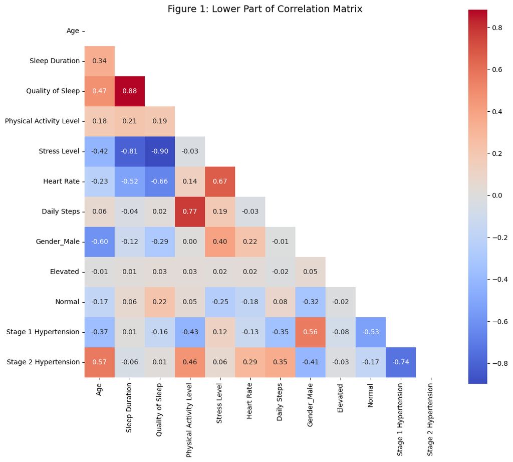

```python
correlation_df = data_encoded[['Age','Sleep Duration','Quality of Sleep', 'Physical Activity Level','Stress Level','Heart Rate','Daily Steps','Gender_Male','Elevated','Normal','Stage 1 Hypertension','Stage 2 Hypertension']]
correlation_matrix = correlation_df.corr()
mask = np.triu(np.ones_like(correlation_matrix, dtype=bool))
#  可视化相关系数矩阵的下半部分
plt.figure(figsize=(12, 10))
sns.heatmap(correlation_matrix, mask=mask, annot=True, cmap='coolwarm', fmt=".2f", square=True)
plt.title('Figure 1: Lower Part of Correlation Matrix',fontsize = 14)
plt.show()
```

由相关系数矩阵信息，欲以心率（Heart Rate）作为指标，应该考虑年龄（Age），睡眠时间（Sleep Duration）,睡眠质量（Quality of Sleep）,压力水平（Stress Level）性别（Gender）等因素与心率指标的相关性。

# 使用统计图探索关键变量之间的分布

## 心率和性别

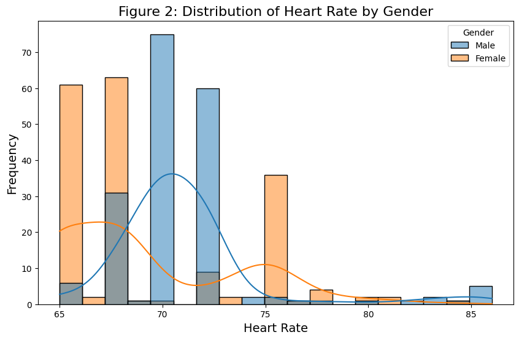

```python
plt.figure(figsize=(10, 6))
sns.histplot(data=data, x='Heart Rate', hue='Gender', kde=True)
plt.title('Figure 2: Distribution of Heart Rate by Gender',fontsize = 16)
plt.xlabel('Heart Rate',fontsize = 14)
plt.ylabel('Frequency',fontsize = 14)
plt.show()
```

## 按性别划分的心率与年龄分布

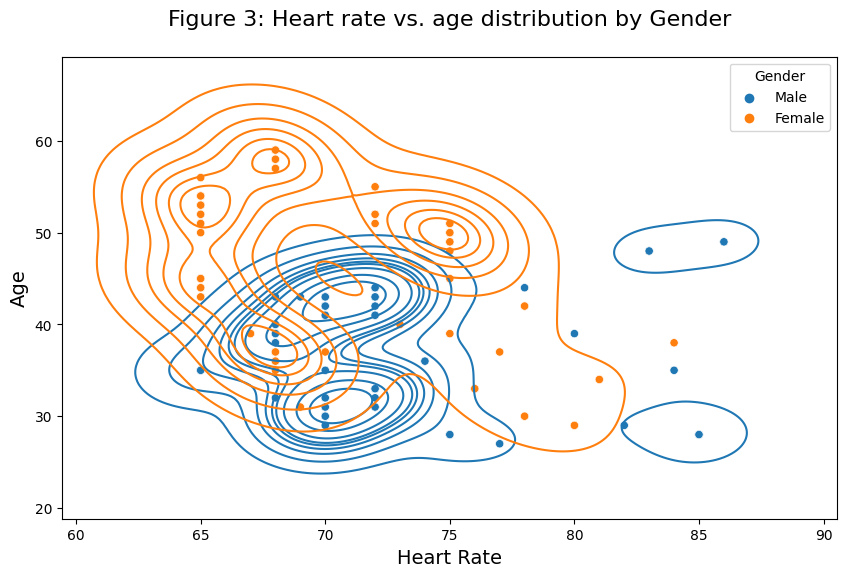

```python
fig,ax = plt.subplots(figsize = (10,6))
sns.kdeplot(data=data, x='Heart Rate', y='Age',hue='Gender')
sns.scatterplot(data=data, x='Heart Rate', y='Age',hue='Gender')
ax.set_xlabel('Heart Rate',fontsize = 14);ax.set_ylabel('Age',fontsize = 14)
ax.set_title('Figure 3: Heart rate vs. age distribution by Gender',
             y = 1.05,fontsize = 16)
plt.show()
```

## 按性别划分的心率与睡眠持续时间

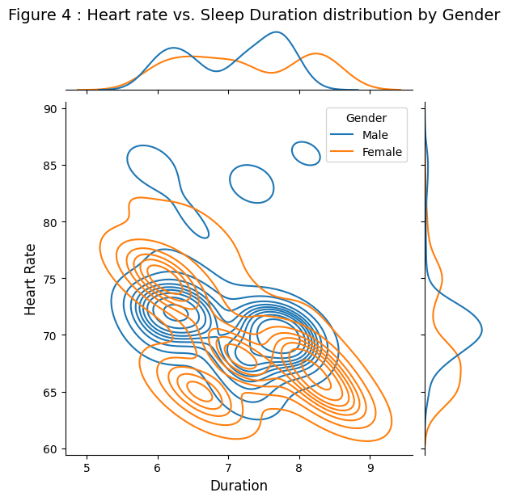

```python
joint = sns.jointplot(data = data , x = 'Sleep Duration' , y = 'Heart Rate' ,
               hue = 'Gender',kind='kde',size = 10,)

plt.suptitle('Figure 4 : Heart rate vs. Sleep Duration distribution by Gender',y = 1.02,fontsize = 14)
plt.xlabel('Duration',fontsize=12);plt.ylabel('Heart Rate',fontsize = 12)
plt.show()
```

> **注： Figure 4 中心的曲线为等距等高线，数据越集中时“山峰”越高，等距等高线越密集；边缘的曲线为高斯核密度估计曲线（Kernel Density Estimation，KDE），用于传达变量的边缘分布信息。**

由Figure 4 中的信息能直观地感受到男女在睡眠特征上的**微小差异性**（睡眠指标：睡眠时间和睡眠平均心率），对本数据而言 **男性睡眠时的平均心率分布主要集中在68-72之间，而女性则是更加偏低主要分布在65-68之间**

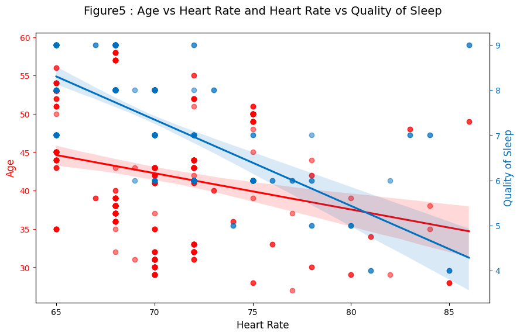

```python
# 创建一个图形和第一个轴
fig, ax1 = plt.subplots(figsize = (10,6))

# 第一个图表：年龄与心率的关系
sns.regplot(y='Age', x='Heart Rate', data=data, ax=ax1,
            scatter_kws={'alpha':0.5},color='red') ## type: ignore
ax1.set_xlabel('Heart Rate',fontsize=12)
ax1.set_ylabel('Age', color='red',fontsize=12)
ax1.tick_params('y', colors='red')

ax2 = ax1.twinx()
# 第二个图表：心率与睡眠质量的关系
sns.regplot(x='Heart Rate', y='Quality of Sleep', data=data, ax=ax2,
            scatter_kws={'alpha':0.5},color='#0070C0') ## type: ignore
ax2.set_ylabel('Quality of Sleep', color='#0070C0',fontsize=12)
ax2.tick_params('y', colors='#0070C0')
# 设置标题
plt.title('Figure5 : Age vs Heart Rate and Heart Rate vs Quality of Sleep',y=1.05,fontsize = 14)
# 显示图表
plt.show()
```

Figure 5 中的阴影部分表示置信区间带，显著性水平 $\alpha = 0.05 $（默认为国际标准）从上图直观发现置信区间带从左至右越来越宽，而置信区间带的宽度代表了模型预测的不确定性。**说明数据点在自变量较高值时更加分散**，那么模型对于这些点的预测将具有更大的变异性。那么以心率数据为横轴，实际检测时，置信区间带的宽度大于某一预设的值，则可以认为，此数据较总体而言是异常的，**此异常可以初步作为用户并没有进入睡眠的依据**。并且由图中信息所得，睡眠心率和年龄，睡眠质量都成负相关。年龄越大，平均睡眠心率越低，睡眠质量越好，平均睡眠心率越低。

## 心率与压力水平

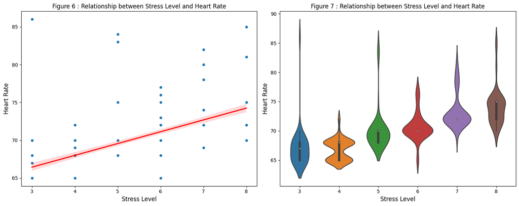

```python
# 心率与压力水平
fig , axes = plt.subplots(1,2,figsize = (15,6))
sns.scatterplot(x='Stress Level', y='Heart Rate', data=data,ax = axes[0])
sns.regplot(x='Stress Level', y='Heart Rate', data=data, scatter=False, color='red',ax=axes[0])

axes[0].set_title('Figure 6 : Relationship between Stress Level and Heart Rate')
axes[0].set_xlabel('Stress Level',fontsize = 12)
axes[0].set_ylabel('Heart Rate',fontsize = 12)

sns.violinplot(x='Stress Level', y='Heart Rate', data=data,ax = axes[1])
axes[1].set_title('Figure 7 : Relationship between Stress Level and Heart Rate')
axes[1].set_xlabel('Stress Level',fontsize = 12)
axes[1].set_ylabel('Heart Rate',fontsize = 12)
plt.tight_layout()
```

Figure 6 直观展示了心率与压力水平的正相关关系：压力水平较高的人群往往拥有更高的睡眠心率；Figure 7 能直观感受到其分布的区间，其细尾部分可以认为是异常数据。

```python
data_encoded # 数据展示
```

|  | Person ID | Age | Occupation | Sleep Duration | Quality of Sleep | Physical Activity Level | Stress Level | BMI Category | Blood Pressure | Heart Rate | Daily Steps | Sleep Disorder | Gender_Male | Systolic BP | Diastolic BP | Blood Pressure Category | Elevated | Normal | Stage 1 Hypertension | Stage 2 Hypertension |
| --- | --- | --- | --- | --- | --- | --- | --- | --- | --- | --- | --- | --- | --- | --- | --- | --- | --- | --- | --- | --- |
| 0 | 1 | 27 | Software Engineer | 6.1 | 6 | 42 | 6 | Overweight | 126/83 | 77 | 4200 | Unknown | True | 126 | 83 | Stage 1 Hypertension | False | False | True | False |
| 1 | 2 | 28 | Doctor | 6.2 | 6 | 60 | 8 | Normal | 125/80 | 75 | 10000 | Unknown | True | 125 | 80 | Stage 1 Hypertension | False | False | True | False |
| 2 | 3 | 28 | Doctor | 6.2 | 6 | 60 | 8 | Normal | 125/80 | 75 | 10000 | Unknown | True | 125 | 80 | Stage 1 Hypertension | False | False | True | False |
| 3 | 4 | 28 | Sales Representative | 5.9 | 4 | 30 | 8 | Obese | 140/90 | 85 | 3000 | Sleep Apnea | True | 140 | 90 | Stage 2 Hypertension | False | False | False | True |
| 4 | 5 | 28 | Sales Representative | 5.9 | 4 | 30 | 8 | Obese | 140/90 | 85 | 3000 | Sleep Apnea | True | 140 | 90 | Stage 2 Hypertension | False | False | False | True |
| ... | ... | ... | ... | ... | ... | ... | ... | ... | ... | ... | ... | ... | ... | ... | ... | ... | ... | ... | ... | ... |
| 369 | 370 | 59 | Nurse | 8.1 | 9 | 75 | 3 | Overweight | 140/95 | 68 | 7000 | Sleep Apnea | False | 140 | 95 | Stage 2 Hypertension | False | False | False | True |
| 370 | 371 | 59 | Nurse | 8.0 | 9 | 75 | 3 | Overweight | 140/95 | 68 | 7000 | Sleep Apnea | False | 140 | 95 | Stage 2 Hypertension | False | False | False | True |
| 371 | 372 | 59 | Nurse | 8.1 | 9 | 75 | 3 | Overweight | 140/95 | 68 | 7000 | Sleep Apnea | False | 140 | 95 | Stage 2 Hypertension | False | False | False | True |
| 372 | 373 | 59 | Nurse | 8.1 | 9 | 75 | 3 | Overweight | 140/95 | 68 | 7000 | Sleep Apnea | False | 140 | 95 | Stage 2 Hypertension | False | False | False | True |
| 373 | 374 | 59 | Nurse | 8.1 | 9 | 75 | 3 | Overweight | 140/95 | 68 | 7000 | Sleep Apnea | False | 140 | 95 | Stage 2 Hypertension | False | False | False | True |

374 rows × 20 columns

## 男女睡眠差异性的假设检验

> **注： 由于假设检验的总体具有惰性，假设检验结果倾向于支持原假设（null hypothesis）$H_0$，即使在面对证据表明备择假设（alternative hypothesis）$H_1$可能更合理的情况下**。故而选取以下假设

原假设$H_0$ : 男女睡眠没有明显差异 ，$\mu_1 = \mu_2$；备选假设$H_1$ : 男女睡眠有明显差异 ,$\mu_1 \neq \mu_2$;显著性水平$\alpha = 0.05$(默认国际标准)

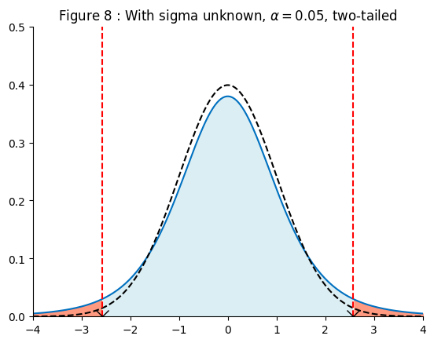

```python
x   = np.linspace(start = -4, stop = 4, num = 200)
n = 6
f_x_t = stats.t.pdf(x, df = n-1)
f_x_norm = stats.norm.pdf(x)
alpha = 0.05

crit_value = stats.t.ppf(q = 1-alpha/2, df = n-1)

fig, ax = plt.subplots()

plt.plot(x, f_x_t, color = "#0070C0")
plt.plot(x, f_x_norm, color = "k", linestyle = '--')

plt.fill_between(x[np.logical_and(x >= -crit_value, x <= crit_value)],
                 f_x_t[np.logical_and(x >= -crit_value, x <= crit_value)],
                 color = "#DBEEF3")

ax.axvline(x = crit_value,  color = 'r', linestyle = '--')
plt.plot(crit_value, 0,marker = 'x', color = 'k', markersize = 12)
ax.axvline(x = -crit_value, color = 'r', linestyle = '--')
plt.plot(-crit_value,0,marker = 'x', color = 'k', markersize = 12)

plt.fill_between(x[x <= -crit_value], f_x_t[x <= -crit_value], color = "#FF9980")
plt.fill_between(x[x >= crit_value],  f_x_t[x >= crit_value], color = "#FF9980")

plt.title("Figure 8 : With sigma unknown, $\\alpha = 0.05$, two-tailed")
ax.set_xlim(-4,4)
ax.set_ylim(0,0.5)
ax.spines['top'].set_visible(False)
ax.spines['right'].set_visible(False)

plt.show()
```

选取统计量: $$T = \frac{\overline{X} - \mu }{S}\sqrt{n} \sim t(n-1)$$

上图为t检验示意图，其中红色区域即为$H_0$的拒绝域${\mathfrak{H} _{0} = \{ |T|> t_{1-\frac{\alpha}{2}} \} }$，单边区域面积为:$\alpha / 2 = 0.025$

```python
male_sleep_duration = data_encoded[data_encoded['Gender_Male'] == True]['Sleep Duration']
female_sleep_duration = data_encoded[data_encoded['Gender_Male'] == False]['Sleep Duration']
t_stat, p_value = stats.ttest_ind(male_sleep_duration, female_sleep_duration)
print('T-statistic:', t_stat)
print('P-value:', p_value)
```

```
T-statistic: -2.3624469898393397
P-value: 0.01866885927060746
```

独立两样本t检验的结果揭示了男性和女性在睡眠时长上存在统计学上的显著差异 $（T = -2.36, p = 0.0187 ,\alpha=0.05,p<\alpha / 2）$则统计量处于拒绝域$\mathfrak{H} _{0}$当中.这表明有证据拒绝零假设$ H_0 $，暗示两个性别之间在睡眠时长上存在差异。具体来说，男性平均睡眠时长比女性短，这在数据集中得到了体现。负的t统计量意味着这种差异，其大小表明了这种差异相对于睡眠时长数据变异性的强度。总体而言，这些发现突出了男性和女性在睡眠模式上的显著差异，强调了可能与性别相关的对睡眠行为的影响。此假设决策对于产品的设计尤为关键。

```python
# 选择感兴趣的变量
variables_of_interest = ['Age', 'Physical Activity Level', 'Sleep Duration']
subset_data = data_encoded[variables_of_interest]
subset_data
```

|  | Age | Physical Activity Level | Sleep Duration |
| --- | --- | --- | --- |
| 0 | 27 | 42 | 6.1 |
| 1 | 28 | 60 | 6.2 |
| 2 | 28 | 60 | 6.2 |
| 3 | 28 | 30 | 5.9 |
| 4 | 28 | 30 | 5.9 |
| ... | ... | ... | ... |
| 369 | 59 | 75 | 8.1 |
| 370 | 59 | 75 | 8.0 |
| 371 | 59 | 75 | 8.1 |
| 372 | 59 | 75 | 8.1 |
| 373 | 59 | 75 | 8.1 |

374 rows × 3 columns

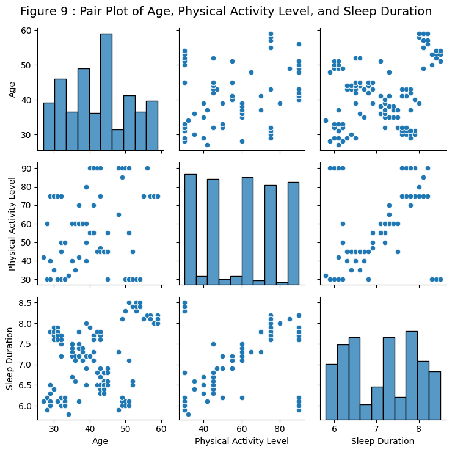

```python
sns.pairplot(data = subset_data )
plt.suptitle('Figure 9 : Pair Plot of Age, Physical Activity Level, and Sleep Duration', fontsize=14)
plt.tight_layout()
plt.show()
```

> 成对关系图的分析显示，年龄、体力活动水平和睡眠时长之间没有强烈的相关性。

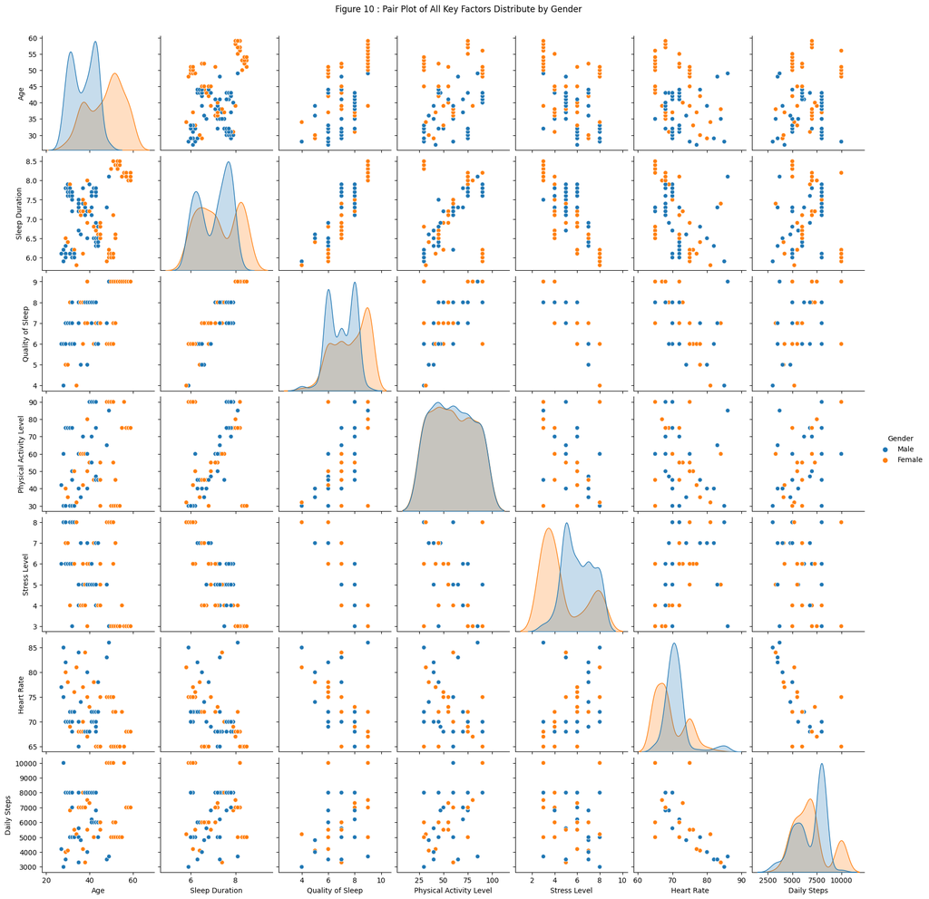

```python
# 全局关键变量的关系 （按性别划分）
sns.pairplot(data=data.drop('Person ID',axis=1),hue='Gender',)
plt.suptitle('Figure 10 : Pair Plot of All Key Factors Distribute by Gender ',y = 1.02)
# plt.legend()
plt.show()
```

由上图全局的pairplot能够直观的各变量之间成对联合分布的关系

# 总结评论📝

**1.结论总结：**  
心率数据在这份睡眠健康与生活方式的数据集中显示了与个体的年龄、性别、压力水平、和睡眠质量的潜在联系。整体来看，心率数值随着个体年龄的增长而有所变化，但并非呈现严格的线性关系。例如，一些年龄较大的参与者（如50岁以上）拥有相对较低的心率（如65左右），这可能与年龄增长伴随的生理变化有关。  
性别方面，数据集中的男性和女性心率只有微小差别，没有明显的差异。这可能意味着在所记录的年龄范围内，性别对心率的影响并不显著。  
睡眠质量与心率之间的关系在数据中表现出一定的相关性。一些拥有较高睡眠质量评分的参与者往往有较低的心率，这可能表明良好的睡眠有助于维持较低的心率水平，从而有益于心血管健康。  
然而，需要注意的是，有关联并不等于有因果，这些观察到的关系并不能确定因果关系，因为心率受到多种因素的影响，包括生活方式、健康状况、遗传因素等。此外，数据集的样本量和特定变量的分布可能影响分析结果的普适性。因此，要得出确切结论，需要更深入的统计分析和可能的长期跟踪研究。  
**2.对项目的指导意义：**  
（该数据集暗含了各类指标对于睡眠的关联，通过数据分析与可视化的处理，各类变量的关系直观的展现在我们眼前，此处还附带了底层的处理方式和代码,便于他人校对。）

- 睡眠质量与心率的关系：数据可以帮助分析睡眠质量评分与心率之间的关系。如果数据显示高质量睡眠与较低的心率有关联，这可以支持开发>监测心率变化来推断睡眠质量的功能。
- 压力水平与心率的关联：分析压力水平与心率之间的联系，可以指导设备在检测到高压力水平时发出警告或提供放松指导的功能。
- 不同人群与睡眠模式：数据显示不同职业的个体可能有不同的睡眠模式和心率变化。这有助于定制设备，以满足不同用户群体的需求。
- 年龄与心率的关系：分析年龄对心率的影响，可以帮助调整设备对于心率正常范围的预设，使其适应不同年龄段的用户。
- BMI与健康风险：数据中的BMI分类可以帮助理解不同体重指数对心率和睡眠质量的潜在影响，从而在设备中加入健康风险评估功能。
- 睡眠障碍的识别：数据中记录了如失眠和睡眠呼吸暂停等睡眠障碍，分析这些数据有助于开发能够识别和分类睡眠障碍的算法。
- 生活方式因素的考量：体力活动水平、血压和每日步数等数据可以帮助理解生活方式因素如何影响心率和睡眠质量，进而在设备中加入改善生活>方式的建议。
- 数据趋势和模式：通过分析数据中的长期趋势和模式，可以为设备提供预测功能，比如预测用户在特定条件下可能出现的睡眠问题。
- 个性化设置：根据数据分析结果，设备可以提供个性化的设置选项，比如根据用户的心率变化范围、睡眠时长和质量来调整监测参数。

> **注：由于不同人群睡眠的差异性，产品的设计想要面向所有人群就需要考虑这种差异性，即上述讨论的影响因素，故而本项目产品的设计有较强的机器学习的逻辑在其中。而本产品的机器学习算法的底层逻辑就是上述数据分析的结果，所以该数据分析和进一步的数学统计模型的建立对于本项目而言是尤为重要的！**